# reproducing li et al 2018

anjie

8/6/2021

# data prep

```r
d_clean <- d %>%
  mutate(
    age = case_when(
      Age == -1 ~ "kid",
      Age == 1 ~ "adult",
      TRUE ~ "NA"
    ),
    culture = case_when(
      Culture == -1 ~ "US",
      Culture == 1 ~ "CN",
      TRUE ~ "NA"
    )
  ) %>%
  rename(
    participant = Participant,
    control_yes_greg = `Control statements`,
    control_yes_walter = X5,
    control_yes_james = X6,
    control_no_owen = X7,
    control_no_leo = X8,
    control_no_jason = X9,
    control_no_alvin = X10,
    control_no_blaze = X11,
    test_peter = `Critical statements`,
    test_pickes = X13

  ) %>%
  select(participant, age, culture, starts_with("control"), starts_with("test")) %>%
  filter(!is.na(participant))

d_clean
```

```
## # A tibble: 164 x 13
##    participant age   culture control_yes_greg control_yes_walt… control_yes_jam…
##          <dbl> <chr> <chr>   <chr>            <chr>             <chr>
##  1           1 kid   US      1                1                 1
##  2           2 kid   US      1                1                 1
##  3           3 kid   US      1                1                 1
##  4           4 kid   US      1                1                 1
##  5           5 kid   US      1                1                 1
##  6           6 kid   US      1                1                 1
##  7           7 kid   US      1                0                 1
##  8           8 kid   US      0                1                 0
##  9           9 kid   US      1                1                 1
## 10          10 kid   US      1                1                 0
## # … with 154 more rows, and 7 more variables: control_no_owen <chr>,
## #   control_no_leo <chr>, control_no_jason <chr>, control_no_alvin <chr>,
## #   control_no_blaze <chr>, test_peter <chr>, test_pickes <chr>
```

```r
d_long <- d_clean %>%
  pivot_longer(cols = c(starts_with("control"), starts_with("test")),
               names_to = "response_type",
               values_to = "response") %>%
  mutate(
    type = case_when(
      grepl("control_yes", response_type) ~ "control_yes",
      grepl("control_no", response_type) ~ "control_no",
      grepl("test", response_type) ~ "test"
    )
  )

d_long
```

```
## # A tibble: 1,640 x 6
##    participant age   culture response_type      response type
##          <dbl> <chr> <chr>   <chr>              <chr>    <chr>
##  1           1 kid   US      control_yes_greg   1        control_yes
##  2           1 kid   US      control_yes_walter 1        control_yes
##  3           1 kid   US      control_yes_james  1        control_yes
##  4           1 kid   US      control_no_owen    1        control_no
##  5           1 kid   US      control_no_leo     1        control_no
##  6           1 kid   US      control_no_jason   1        control_no
##  7           1 kid   US      control_no_alvin   1        control_no
##  8           1 kid   US      control_no_blaze   0        control_no
##  9           1 kid   US      test_peter         1        test
## 10           1 kid   US      test_pickes        1        test
## # … with 1,630 more rows
```

# reproducing raw percentage

## table1

```r
d_long %>%
  group_by(age, culture, type) %>%
  filter(grepl("control", response_type)) %>%
  summarise(
    percentage_of_correct = mean(as.numeric(response), na.rm = TRUE)
  )
```

```
## # A tibble: 8 x 4
## # Groups:   age, culture [4]
##   age   culture type        percentage_of_correct
##   <chr> <chr>   <chr>                       <dbl>
## 1 adult CN      control_no                  0.987
## 2 adult CN      control_yes                 0.915
## 3 adult US      control_no                  0.949
## 4 adult US      control_yes                 0.929
## 5 kid   CN      control_no                  0.8
## 6 kid   CN      control_yes                 0.8
## 7 kid   US      control_no                  0.845
## 8 kid   US      control_yes                 0.858
```

yep everything was as reported

## model

> Controls.lmer = glmer (Correctness ∼ Culture * Age + (1|Participant) + (1|Statement), data = Controls, family = binomial)

```r
glmer(response ~ culture * age + (1|participant) + (1|response_type),
      data = filter(d_long, grepl("control", response_type)) %>% mutate(response = as.factor(response)),
      family = "binomial") %>%
  summary()
```

```
## Generalized linear mixed model fit by maximum likelihood (Laplace
##   Approximation) [glmerMod]
##  Family: binomial  ( logit )
## Formula: response ~ culture * age + (1 | participant) + (1 | response_type)
##    Data:
## filter(d_long, grepl("control", response_type)) %>% mutate(response = as.factor(response))
##
##      AIC      BIC   logLik deviance df.resid
##    804.0    835.1   -396.0    792.0     1306
##
## Scaled residuals:
##     Min      1Q  Median      3Q     Max
## -4.6040  0.1809  0.2272  0.3502  0.8591
##
## Random effects:
##  Groups        Name        Variance Std.Dev.
##  participant   (Intercept) 0.4094   0.6398
##  response_type (Intercept) 0.1503   0.3877
## Number of obs: 1312, groups:  participant, 164; response_type, 8
##
## Fixed effects:
##                  Estimate Std. Error z value Pr(>|z|)
## (Intercept)        3.4372     0.3354  10.247  < 2e-16 ***
## cultureUS         -0.4069     0.3755  -1.084   0.2786
## agekid            -1.9018     0.3562  -5.339 9.36e-08 ***
## cultureUS:agekid   0.7991     0.4708   1.697   0.0896 .
## ---
## Signif. codes:  0 '***' 0.001 '**' 0.01 '*' 0.05 '.' 0.1 ' ' 1
##
## Correlation of Fixed Effects:
##             (Intr) cltrUS agekid
## cultureUS   -0.644
## agekid      -0.733  0.606
## cultrUS:gkd  0.530 -0.798 -0.745
```

> To determine whether there were any cultural differences in the responses to the control statements, a binomial mixed-effects model was constructed using the R programming language, with culture, age and their interaction as fixed effects and participant and statement as random effects.3 We found a main effect of age (z = 6.274, p < 0.001) but no main effect of culture (z = 0.031, p > 0.1) and no interaction between age and culture (z = 1.697, p > 0.05). Separate analyses of the responses to Yes-controls and No-controls also found no reliable effects or interactions of culture (all p’s > 0.1).

not so sure where the number comes from

# critical

## descriptive

```r
d_critic_test <- d_long %>%
  group_by(age, culture, type) %>%
  filter(grepl("test", response_type)) %>%
  summarise(
    percentage_of_correct = mean(as.numeric(response), na.rm = TRUE)
  )
```

try the model

```r
glmer(response ~ culture * age + (1|participant) + (1|response_type),
      data = filter(d_long, grepl("test", response_type)) %>% mutate(response = as.factor(response)),
      family = "binomial") %>%
  summary()
```

```
## Generalized linear mixed model fit by maximum likelihood (Laplace
##   Approximation) [glmerMod]
##  Family: binomial  ( logit )
## Formula: response ~ culture * age + (1 | participant) + (1 | response_type)
##    Data:
## filter(d_long, grepl("test", response_type)) %>% mutate(response = as.factor(response))
##
##      AIC      BIC   logLik deviance df.resid
##    413.5    436.3   -200.8    401.5      322
##
## Scaled residuals:
##     Min      1Q  Median      3Q     Max
## -1.2168 -0.4599  0.2944  0.4090  1.1934
##
## Random effects:
##  Groups        Name        Variance Std.Dev.
##  participant   (Intercept) 6.25636  2.5013
##  response_type (Intercept) 0.02368  0.1539
## Number of obs: 328, groups:  participant, 164; response_type, 2
##
## Fixed effects:
##                  Estimate Std. Error z value Pr(>|z|)
## (Intercept)       -0.1876     0.5107  -0.367   0.7133
## cultureUS          1.5012     0.7542   1.990   0.0465 *
## agekid            -0.9327     0.8053  -1.158   0.2467
## cultureUS:agekid   0.4880     1.0886   0.448   0.6540
## ---
## Signif. codes:  0 '***' 0.001 '**' 0.01 '*' 0.05 '.' 0.1 ' ' 1
##
## Correlation of Fixed Effects:
##             (Intr) cltrUS agekid
## cultureUS   -0.666
## agekid      -0.591  0.349
## cultrUS:gkd  0.442 -0.594 -0.728
```

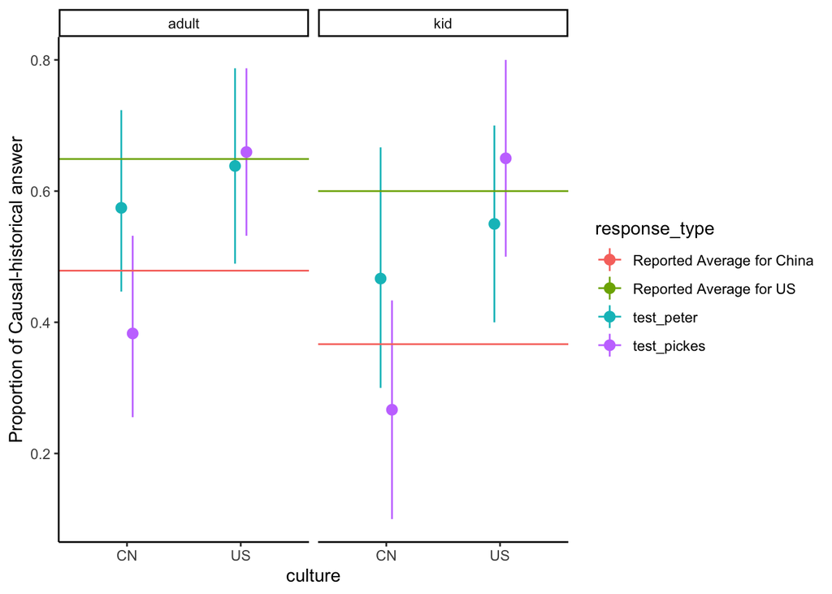

```r
critical_d <- d_long %>%
  group_by(age, culture, type) %>%
  filter(grepl("test", response_type)) %>%
  summarise(
    percentage_of_correct = mean(as.numeric(response), na.rm = TRUE)
  )


d_long %>%
  group_by(age, culture, response_type) %>%
  filter(grepl("test", response_type)) %>%
  ggplot(aes(x = culture, y = as.numeric(response), color = response_type)) +
  stat_summary(fun.data = "mean_cl_boot", position = position_dodge(width = .2))+
  geom_hline(data = critical_d %>%
               mutate(culture_print = case_when(
                 culture == "CN" ~ "Reported Average for China",
                 culture == "US" ~ "Reported Average for US"
               )), aes(x = culture, yintercept = percentage_of_correct,
                                    color = culture_print)) +

  guides(legend = NULL) +
  facet_wrap(~age) +
  theme_classic() +
  ylab("Proportion of Causal-historical answer")
```

maybe the reported CA is inflated…? idk or maybe there’s just a statement that’s worse.

another way to ask the question is: are these four groups of participants equally consistent?

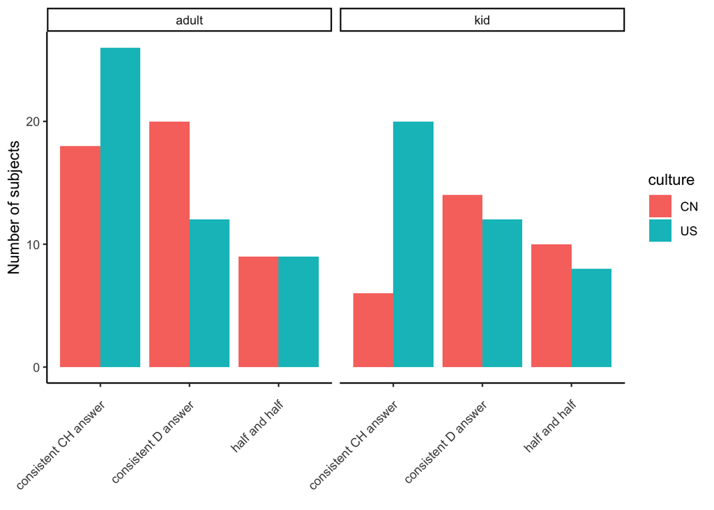

```r
d_long %>%
  group_by(age, culture, response_type) %>%
  filter(grepl("test", response_type)) %>%
  ungroup() %>%
  group_by(participant, age, culture) %>%
  summarise(
    total_test_score = sum(as.numeric(response))
  ) %>%
  mutate(
    consistencty = case_when(
      total_test_score == 2 ~ "consistent CH answer",
      total_test_score == 0 ~ "consistent D answer",
      total_test_score == 1 ~ "half and half"
    )
  ) %>%
  ungroup() %>%
  group_by(culture, age, consistencty) %>%
  summarise(n_subject = n()) %>%
  ggplot(aes(x = consistencty, y = n_subject, fill = culture)) +
  geom_col(position = position_dodge()) +
  facet_grid( ~ age) +
  ylab("Number of subjects") +
  theme_classic() +
  theme(axis.text.x = element_text(angle = 45, vjust = .9, hjust = 1)) +
  xlab("")
```